# Predykcja zachorowalności na raka piersi w Polsce

Konrad Czechowski, Kamil Koziej, Bartosz Piotrowski, Jakub Tyrek

June 14, 2016

# Dane

Model predykcyjny zbudowaliśmy w oparciu o następujące dane: * wskaźniki zachorowalności w latach 2010 i 2011, * wskaźniki urbanizacji w powiatach i grupach wiekowych, * wielkości powiatów. Przesłanką uzasadniającą dołączenie wskaźnika urbanizacji do danych było jego istotne skorelowanie z zachorowalnością. Przykładowe dane:

```r
dane <- read.csv('wskazniki.csv')
tail(dane)
```

```
##      teryt    wiek plec liczba urb_grupy X2010 X2011 X2012     wsk_2010
## 4543  1820  <0-44>    K  15908 0.2296958     0     2     2 0.0000000000
## 4544  1820 <45-54>    K   3619 0.2732799     5     1     5 0.0013815971
## 4545  1820 <55-64>    K   3602 0.2651305     1     7    12 0.0002776235
## 4546  1820 <65-74>    K   2077 0.2445835     0     4     4 0.0000000000
## 4547  1820 <75-84>    K   1746 0.2966781     0     4     1 0.0000000000
## 4548  1820     85+    K    551 0.2159710     0     0     1 0.0000000000
##          wsk_2011     wsk_2012
## 4543 0.0001257229 0.0001257229
## 4544 0.0002763194 0.0013815971
## 4545 0.0019433648 0.0033314825
## 4546 0.0019258546 0.0019258546
## 4547 0.0022909507 0.0005727377
## 4548 0.0000000000 0.0018148820
```

# Modele predykcyjne

Naszym celem była predykcja na podstawie danych zachorowalności w grupach wiekowych i powiatach w roku 2012. Przetestowaliśmy kilka popularnych modeli, m. in.: *model liniowy* glmnet *lasy losowe* kNN *SVM regression

Każdy z modeli to tak naprawdę dwa modele - jeden działa na danych dotyczących kobiet, drugi mężczyzn. Przyczyną takiego działania są znaczne różnice w zachorowalności obu płci. Wyżej zaprezentowane dane podzieliliśmy na zbiór teestowy i treningowy w stosunku 70 / 30. W celu dobrania odpowiednich parametrów użyliśmy CV. Żaden z powyższych modeli nie dawał predykcji lepszej, niż proste branie średniej zachorowalności w danej grupie z dwóch lat poprzednich. Porównanie modeli pod względem błędu średniokwadratowego pokazuje wykres słupkowy poniżej. Błąd średniokwadratowy na wykresie to średnia MSE po dziesięciokrotnym powtórzeniu procedury: podziel zbiór na podzbiór treningowy / testowy, stwórz model, policz MSE dla modelu.

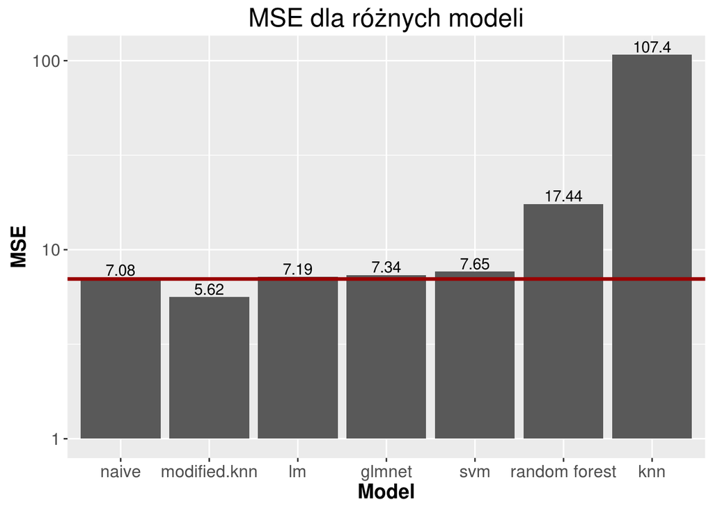

```r
library(plyr)
library(ggplot2)

load("data_for_rmd.rda")


ggplot(dfaggMSE2,aes(x=names,y=values)) +
  geom_bar(stat="identity") +
  scale_y_log10() +
  ylab("MSE") +
  xlab("Model") +
  labs(title = "MSE dla różnych modeli") +
  geom_hline(aes(yintercept=7), colour="#990000", size=1.2) +
  geom_text(aes(label = round(values, 2)), vjust = -0.2) +
  theme(axis.text=element_text(size=12), title=element_text(size=15), axis.title=element_text(size=14,face="bold"))
```

*Naive* oznacza model biorący średnią z lat poprzednich, natomiast modified.knn oznacza stworzony przez nas model, który opisujemy poniżej.

# Nasz model

Z powodu niezadowalających wyników dla typowych modeli, skonstruowaliśmy nasz własny, lepiej przystosowany do danych. Jego idea opiera się na następującej obserwacji: w dużych powiatach wariancja zachorowalności w kolejnych latach jest niewielka, więc zasadne jest branie średniej zachorowalności z lat ubiegłych jako predykcję dla roku kolejnego; natomiast w małych powiatach wariancja zachorowalności jest duża (w porównaniu do wielkości populacji), dlatego w ich przypadku taka predykcja obarczona będzie dużym błędem.

**Model działa następująco:** Niech G będzie danym podzbiorem populacji z zadaną płcią, przedziałem wiekowym i powiatem, dla której chcemy wyznaczyć predykcję zachorowalności. 1. Jeżeli liczebność grupy G przekracza zadany próg k, model zwraca jako predykcję średnią zachorowalność lat poprzednich w grupie G. 2. W przeciwnym razie do danej grupy dobieramy N grup z tego samego województwa i przedziału wiekowego, które mają jak najbliższe wskaźniki urbanizacji, aż do momentu, gdy suma populacji w tych grupach przekroczy zadany próg k. Jako predykcję zwracamy wówczas średnią ważoną zachorowalności w tych grupach w latach poprzednich.

Próg k jest zoptymalizowany dla każdego osobno. Przykłady analizy optymalnego k dla konkretnych grup obrazują dwa wykresy poniżej.

[figure not shown]

```r
ggplot(k.errors, aes(x=k, y=`85+`))+
geom_point(size=2)+
  ggtitle(expression(paste("MSE vs. parametr ",italic("k")," dla grupy <kobiety, 45-54>")))+
ylab("MSE")+
  theme(axis.text.x = element_text(angle = 40, hjust = 1),
        axis.text=element_text(size=10.5), title=element_text(size=14),
        axis.title=element_text(size=14,face="bold"))
```

[figure not shown]

```r
ggplot(k.errors, aes(x=k, y=`<45-54>`))+
  geom_point(size=2)+
  ggtitle(expression(paste("MSE vs. parametr ",italic("k")," dla grupy <kobiety, 85+>")))+
  ylab("MSE")+
  theme(axis.text.x = element_text(angle = 40, hjust = 1),
        axis.text=element_text(size=10.5), title=element_text(size=14),
        axis.title=element_text(size=14,face="bold"))
```

# Kod

```r
# kod do liczenia naszej metody 'modified knn'

wsk.in.closest.k.populations <- function(i,df, k = 100000){
  subpop <- df[i,,drop=FALSE]
  if (subpop$liczba >=k) return(subpop$wsk10_11)
  wiek <- subpop$wiek; woj <- subpop$woj; urb <- subpop$urb_grupy
  similar <- df[(df$woj==woj) & (df$wiek ==wiek),]
  similar <- similar[similar$teryt != subpop$teryt,]
  closest <- order(abs(urb - similar$urb_grupy))
  #similar <- similar[order(abs(urb - similar$urb_grupy)),]
  size <- cumsum(similar$liczba[closest])
  which.big.enough <- which(subpop$liczba + size > k)
  if (length(which.big.enough) == 0) which.big.enough = length(size)
  populations <- rbind(subpop, similar[closest[1:(which.big.enough[1])],])
  return(sum(populations$wsk10_11 * populations$liczba) / sum(populations$liczba))
}

try.k <- function(df, k, check = 1:dim(df)[1]){
  wsk <- sapply(check ,wsk.in.closest.k.populations, k= k, df = df)
  mean(((wsk - df$wsk_2012[check])*df$liczba[check])^2)
}



find.k.for.groups <- function(df, ks){
  age_groups <- c('<0-44>', '<45-54>', '<55-64>', '<65-74>', '<75-84>', '85+')
  naive.err <- rep(NA, length(age_groups))
  best.k <- rep(NA, length(age_groups))
  best.k.err <- rep(NA, length(age_groups))
  i <- 1
  for(age_group in unique(df$wiek)){
    errors <- sapply(ks, try.k, df = df[df$wiek==age_group,])
    best.k[i] <- ks[which.min(errors)]
    i <- i+1
  }
  best.k
}

predict.mknn <- function(best.k, df, on = 1:dim(df)[1]){
  age_groups <- c('<0-44>', '<45-54>', '<55-64>', '<65-74>', '<75-84>', '85+')
  all.predictions <- rep(NA, dim(df)[1])
  for(j in 1:length(age_groups)){
    ix <- which(df$wiek == age_groups[j])
    ix <- ix[ix %in% on]
    pred <- sapply(ix, wsk.in.closest.k.populations, df = df, k=best.k[j])
    all.predictions[ix] <- pred
  }
  all.predictions[!is.na(all.predictions)]
}

###################### porownianie roznych modeli
library(dplyr)
library(tidyr)
library(caret)
library(kernlab)
library(MASS)
library(elasticnet)
library(ranger)
library(foreach)


data <- read.csv('wskazniki.csv')[, 1:8]
dataK <- data %>% filter(plec == 'K')#kazda analize robie osobno dla mezczyzn i kobiet
dataM <- data %>% filter(plec == 'M')
myformula <- as.formula("X2012 ~ X2010 + X2011 + liczba + urb_grupy + wiek")

library(snow)
cl <- makeCluster(3)
clusterEvalQ(cl, {
  library(caret)
  library(dplyr)
  library(foreach)
})

clusterExport(cl, list = list('data', 'dataK', 'dataM', 'get_pred_par', 'get_pred', 'get_pred2', 'pred_to_mse', 'myformula'))

  ######################
  get_pred <- function(method_str, train_dK, train_dM, test_dK, test_dM, formula){
    modelK <- train(formula, data = train_dK, method = method_str)
    modelM <- train(formula, data = train_dM, method = method_str)
    test_dK$prediction <- predict(modelK, newdata = test_dK[, -8])
    test_dM$prediction <- predict(modelM, newdata = test_dM[, -8])
    test_d <- rbind(test_dK, test_dM)
    return(test_d$pred)
  }
  get_pred2 <- function(method_str){
    return(get_pred(method_str, trainingK, trainingM, testK, testM, myformula))
  }
  pred_to_mse <- function(pred){
    mse <- (pred - test$X2012) ^ 2 %>% mean
    return(mse)
  }
  get_pred_par <- function(methods_str){
    preds <- foreach(m = methods_str, .combine = 'cbind') %do% (m %>% get_pred2)
    preds <- preds %>% as.data.frame
    colnames(preds) <- methods_str
    return(preds)
  }
  #########################################

MSE <- replicate(10,{
  inTrain <- createDataPartition(data$X2012, p = 0.7, list = FALSE)
  trainingK <- dataK[inTrain, ] %>% as.data.frame()
  testK <- dataK[-inTrain, ] %>% as.data.frame()
  trainingM <- dataM[inTrain, ] %>% as.data.frame()
  testM <- dataM[-inTrain, ] %>% as.data.frame()
  test <- rbind(testK, testM)
  mse <- NULL
  predictions <- get_pred_par(c('lm','glmnet','knn','svmLinear','ranger'))
  colMeans((predictions - test$X2012)^2)
})

#naiwny - srednia z dwoch lat
naivePrediction <- (data$X2010 + data$X2011) / 2
msenaive <- mean((naivePrediction - data$X2012)^2)

aggMSE <- colMeans(t(MSE))
aggMSE$naive <- msenaive

load('mse_modified_knn')

aggMSE$modified.knn <- mse.knn

save(aggMSE, file='MSE_comparison')
  #########################################
```